# Introduction to Data Frames

20 September 2020

## Outcomes

- Select subsets of rows of data frames
- Manipulate data frames, for example, defining columns and permuting rows
- Create line plots and comparative boxplots

## Background

Several [lightning fires](https://www.fire.ca.gov/incidents/2020/8/16/czu-lightning-complex-including-warnella-fire/) began after August 15th, 2020 in California. How did this affect air quality?

One way to measure air quality after a fire is by particulate matter in the air. According to the [Environmental Protection Agency](https://www.epa.gov/pm-pollution/particulate-matter-pm-basics) (EPA) “PM stands for particulate matter (also called particle pollution): the term for a mixture of solid particles and liquid droplets found in the air. Some particles, such as dust, dirt, soot, or smoke, are large or dark enough to be seen with the naked eye. … PM2.5 : fine inhalable particles, with diameters that are generally 2.5 micrometers and smaller.” In this assignment, we’ll analyze data provided by the [EPA daily outdoor air quality](https://www.epa.gov/outdoor-air-quality-data/download-daily-data).

## Instructions

- Answer the following questions, and show all your R code.
- Upload your submission to Canvas in nicely formatted HTML generated from Rstudio.
- Hint: The following functions will help you. `as.Date, plot, boxplot, order`

# Questions

Load the data.

```r
air = read.csv("http://webpages.csus.edu/fitzgerald/files/stat128/fall20/ad_viz_plotval_data.csv")
```

## 1

> Pick a site from the column `Site.Name` in the data that you find personally interesting, and select the rows in the data frame that correspond to that site. Use this subset for the remainder of the analysis. Mention why this site interests you.

```r
data = air[air[,"Site.Name"] == "Davis-UCD Campus",]
# air = air[air[,"Site.Name"] == "Davis-UCD Campus",]
data[,"Date"] = as.Date(x = data[,"Date"], format = "%m/%d/%Y")


# alternatively
# data = air[air$Site.Name == 'Davis-UCD Campus',]
# data$Date = as.Date(x = data$Date, format = "%m/%d/%Y")
```

I picked Site.Name with the value ‘Davis-UCD Campus’ because I live in Davis.

## 2

> Plot a line plot of the columns `Daily.Mean.PM2.5.Concentration` as a function of `Date`. Start one month before the fire and go to the end of the data set. Comment on what the graph shows.

> The fires started on 8-15-2020 so I will use data starting on 7-15-2020.

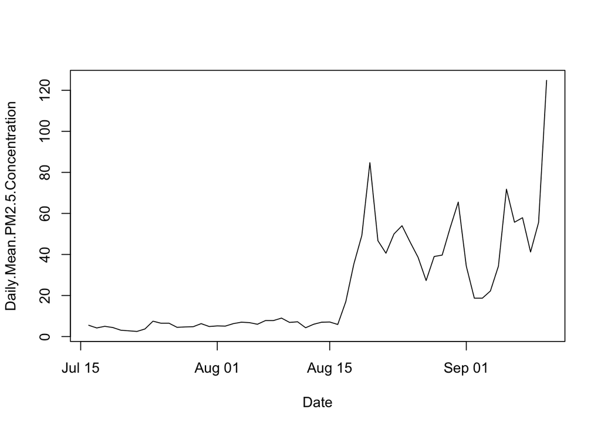

```r
boolean_mask = data[,"Date"] > as.Date("2020-07-15")
fire_data = data[boolean_mask,]
plot(Daily.Mean.PM2.5.Concentration ~ Date, type = "l", data = fire_data)
```

```r
# with(data = data, plot(Daily.Mean.PM2.5.Concentration~Date, type = "l"))
```

This graph shows that before the fire the daily mean pm2.5 concentration was relatively low. After August 15 (the day the fires started) the daily mean pm2.5 concentration increased significantly. We can also see another massive increase more recently likely caused by the additional fire outbreaks.

## 3

> Create a comparative boxplot of “Daily.Mean.PM2.5.Concentration” in the month before the fire and the month after the fire. Comment on what the boxplots show. Hint: create a new column that indicates if the observation happened before or after the fire.

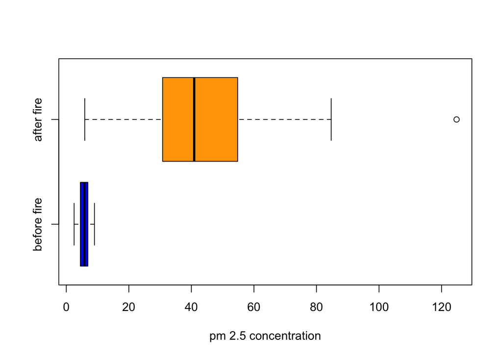

```r
# this is the data seperated before and after the fire started
before_fire_boolean_mask = data[,"Date"] < as.Date("2020-08-15") & data[,"Date"] > as.Date("2020-07-15")
after_fire_boolean_mask = data[,"Date"] >= as.Date("2020-08-15")

before_fire = data[before_fire_boolean_mask,]
after_fire = data[after_fire_boolean_mask,]

boxplot_fire =boxplot(before_fire$Daily.Mean.PM2.5.Concentration, after_fire$Daily.Mean.PM2.5.Concentration, horizontal = TRUE, names = c("before fire", "after fire"), xlab="pm 2.5 concentration", col = c("blue","orange"))
```

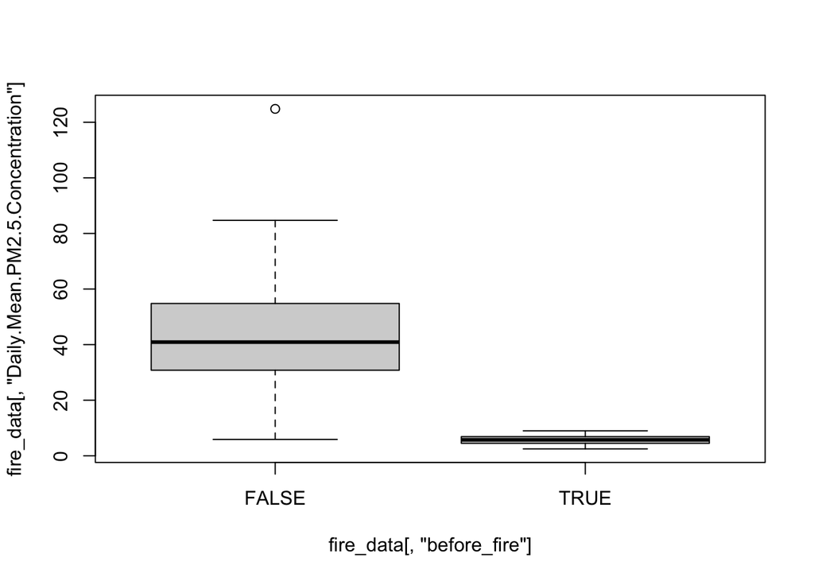

```r
# using a column that indicates  if fire happened before or after the fire
fire_data[,"before_fire"] = fire_data[,"Date"] < as.Date("2020-08-15")
boxplot(fire_data[,"Daily.Mean.PM2.5.Concentration"]~fire_data[,"before_fire"])
```

## 4

> Use your work above to implement the function below.

```r
#' Plot the n most recent PM2.5 particle measurements on the y axis, with date as the x axis.
#'
#' @param d data frame containing columns Daily.Mean.PM2.5.Concentration and Date for a single site
#' @param n number of observations to include
plot_pm2.5 = function(d, n = 100)
{
  # ensure date is stored correctly
  d[,"Date"] = as.Date(d[,"Date"], "%m/%d/%Y")
  # to ensure data is sorted
  # d = d[order(d$Date, decreasing = FALSE),]
  # select the last n elements
  n_most_recent = tail(x = d, n = n)
  # plot the data
  plot(Daily.Mean.PM2.5.Concentration ~ Date, data = n_most_recent, type="l")
}
```

> Verify that `plot_pm2.5` works for `n = 100` and `n = 50`.

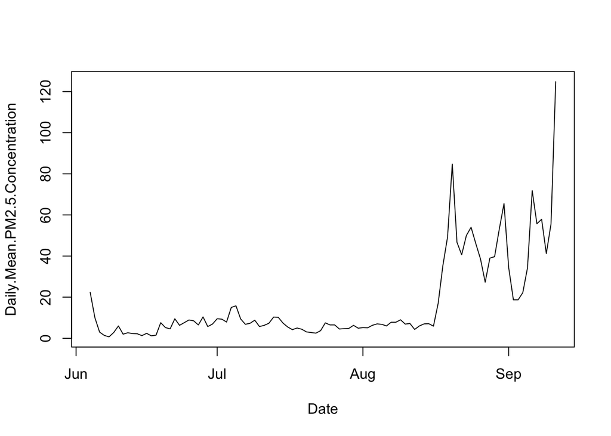

```r
plot_pm2.5(d = data) # n = 100 is default value
```

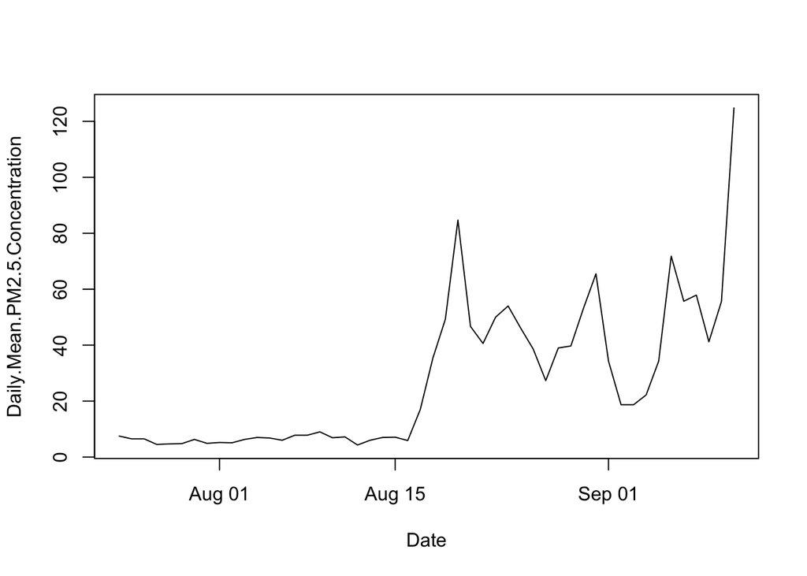

```r
plot_pm2.5(d = data, n = 50)
```